# **Maternal dietary behaviors vs Asthma in children**

##### **Group members:** Juhi Mattekatt (jm5916) and Nichcha Subdee (ns3923)

#### **Final project option 3 (Group assignment)**

**Dataset:** Exposome

**Type:** Hypotheses generation

**Research question:** What maternal dietary behaviors contribute to asthma incidence in offspring?

#### **Background**

Asthma is one of the most common chronic diseases in children worldwide. It affects approximately 4,313 per 100,000 children under 20 years old in 2021 and accounts for more than 1% of global disability-adjusted life years (DALYs) (Kim et al., 2025). Although the global prevalence has declined by about 30% since 1990, asthma is expected to remain a major health burden through 2050, with the highest rates seen in children aged 5–9 years. Early-life and prenatal factors are known to play an important role in asthma development, and maternal health behaviors during pregnancy are one key area of interest. Maternal diet is a modifiable factor that may affect fetal immune development and airway formation, yet it remains unclear which specific dietary behaviors are most strongly linked to childhood asthma. Diet data is very high dimensional with many variables and interaction in between variables, so a machine learning approach may be beneficial, especially with data from the Exposome dataset.

Therefore, this study will apply machine learning approaches to explore the relationship between maternal dietary behaviors during pregnancy and asthma in children aged 6–11 years.

#### **Objective**

- To explore the relationship between maternal dietary behaviors during pregnancy and asthma in children aged 6–11 years.
- To compare the performance of different machine learning algorithms in detecting the relationship between maternal dietary behaviors during pregnancy and childhood asthma risk.
- To determine maternal dietary behaviors during pregnancy that have the greatest risk of leading to asthma in offspring for future research.

#### **Methodology**

This study uses a real world exposome dataset based on the HELIX project database. The HELIX project is a multi-center European birth cohort integrating six longitudinal cohorts from France, Greece, Lithuania, Norway, Spain, and the UK, with children born between 2003 and 2009.

A cohort of 1,301 mother–child pairs was followed up at ages 6–12 years, with health outcomes including doctor-diagnosed asthma, dietary exposures, and sociodemographic characteristics recorded across all centers (Agier et al., 2019). This present analysis uses 8 maternal dietary behaviors in the dataset that may impact asthma incidence.

**Outcome:** `hs_asthma` – Doctor diagnosed asthma (ever)

**Dietary features:** 8 variables for maternal dietary behaviors during pregnancy were found

- `h_cereal_preg_Ter` – cereal consumption during pregnancy (times/week)
- `h_dairy_preg_Ter` – dairy consumption during pregnancy (times/week)
- `h_fastfood_preg_Ter` – fast food consumption during pregnancy (times/week)
- `h_fish_preg_Ter` – fish consumption during pregnancy (times/week)
- `h_fruit_preg_Ter` – fruit consumption during pregnancy (times/week)
- `h_legume_preg_Ter` – legume consumption during pregnancy (times/week)
- `h_meat_preg_Ter` – meat consumption during pregnancy (times/week)
- `h_veg_preg_Ter` – vegetables consumption during pregnancy (times/week)

*Note: All dietary variables are tertile-coded (1 = low, 2 = medium, 3 = high)*

**Covariates:** These five child and maternal covariates are included to reduce the potential influence of sociodemographic and perinatal factors on the dietary exposure–asthma relationship.

- `e3_sex_None` – Child sex (female / male)
- `h_age_None` – Maternal age (years)
- `h_edumc_None` – Maternal education (1: primary school, 2:secondary school, 3:university degree or higher)
- `h_mbmi_None` – Maternal pre-pregnancy body mass index (kg/m2)
- `h_cohort` – Cohort of inclusion (1 to 6)

*Note: In a predictive framework, covariates are included as features rather than being causally controlled for. For Logistic Regression, all features are included by default. For the Elastic Net, a penalty factor of zero was applied to ensure covariates were always retained in the model. For Random Forest, covariates were included as eligible features but were not forced into the model but may be de-prioritized by the algorithm*

**Study Framework:**

1. **Data preparation & cleaning**
2. **Unsupervised learning** (K-Means Clustering)
3. **Data partition** (70/30 stratified train/test split)
4. **Supervised learning with hyperparameter tuning** (10-fold cross-validation)
- Logistic Regression
- Elastic Net
- Random Forest
5. **Model comparison**
6. **Apply model and model evaluation** (AUC-ROC, Sensitivity, Specificity on test set)
7. **Variable importance**
8. **Interpretation, limitations, and ethical considerations**

#### **Pipeline**

**Step 1: Data Preparation & Cleaning**

```r
# Load data
load("exposome.RData")

# Merge all data frames
studydata = merge(exposome, phenotype, by = "ID") |>
  merge(covariates, by = "ID")

# Remove ID
studydata$ID = NULL

# Select variables
diet_vars = c("h_cereal_preg_Ter", "h_dairy_preg_Ter", "h_fastfood_preg_Ter",
               "h_fish_preg_Ter", "h_fruit_preg_Ter", "h_legume_preg_Ter",
               "h_meat_preg_Ter", "h_veg_preg_Ter")

covar_vars = c("e3_sex_None", "h_age_None", "h_edumc_None", "h_mbmi_None", "h_cohort")

df = studydata[, c("hs_asthma", diet_vars, covar_vars)]

# Recode outcome as factor
df$hs_asthma = factor(df$hs_asthma, levels = c(0,1), labels = c("No", "Yes"))

# Ensure dietary variables are ordered factors
df[, diet_vars] = lapply(df[, diet_vars], function(x) factor(x, ordered = TRUE))

# Ensure covariates are correct type
df$e3_sex_None  = as.factor(df$e3_sex_None)
df$h_edumc_None = as.factor(df$h_edumc_None)
df$h_mbmi_None  = as.numeric(df$h_mbmi_None)
df$h_cohort     = as.factor(df$h_cohort)
df$h_age_None   = as.numeric(df$h_age_None)

# Complete-case analysis
df = na.omit(df)
```

```r
# Final dataset dimensions and outcome distribution
dataset = dim(df)
knitr::kable(table(df$hs_asthma), col.names = c("Asthma", "Total"), caption = "Asthma Frequency")
```

Asthma Frequency

| Asthma | Total |
| --- | --- |
| No | 1159 |
| Yes | 142 |

The final analytic dataset contained 1301 mother–child pairs and 14 variables (1 outcome, 8 maternal dietary exposures, 5 covariates). The outcome variable `hs_asthma` showed class imbalance (1,159 children without asthma vs. 142 children with a doctor-diagnosed asthma). This suggests the need for resampling during model training.

**Step 2: Unsupervised Learning — K-Means Clustering**

The optimal number of clusters (k) was determined using two complementary approaches: the gap statistic and the elbow method.

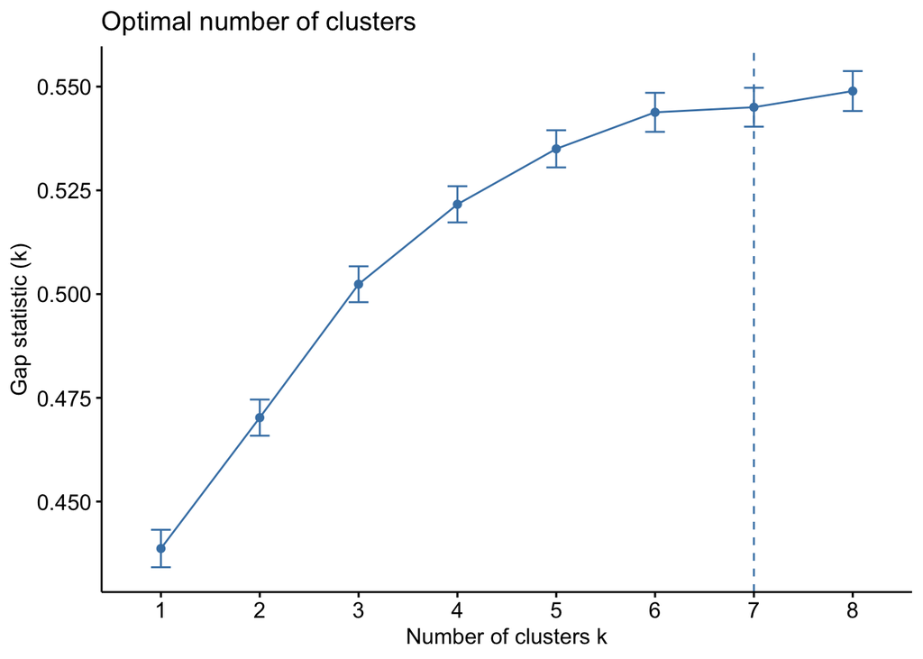

```r
set.seed(123)

diet_matrix = df[, diet_vars] %>%
  mutate(across(everything(), as.numeric)) %>%
  scale()

#Gap-statistic
gap_stat = clusGap(diet_matrix, FUN = kmeans, nstart = 25, K.max = 8, B = 50)
fviz_gap_stat(gap_stat)
```

```r
print(gap_stat, method = "firstmax")
```

```
## Clustering Gap statistic ["clusGap"] from call:
## clusGap(x = diet_matrix, FUNcluster = kmeans, K.max = 8, B = 50, nstart = 25)
## B=50 simulated reference sets, k = 1..8; spaceH0="scaledPCA"
##  --> Number of clusters (method 'firstmax'): 8
##          logW   E.logW       gap      SE.sim
## [1,] 7.138254 7.576942 0.4386885 0.004511392
## [2,] 7.038821 7.509052 0.4702308 0.004357107
## [3,] 6.963001 7.465376 0.5023754 0.004320659
## [4,] 6.907978 7.429612 0.5216343 0.004364138
## [5,] 6.866099 7.401100 0.5350005 0.004478550
## [6,] 6.833878 7.377687 0.5438087 0.004704584
## [7,] 6.811042 7.356069 0.5450273 0.004687058
## [8,] 6.787448 7.336375 0.5489264 0.004809190
```

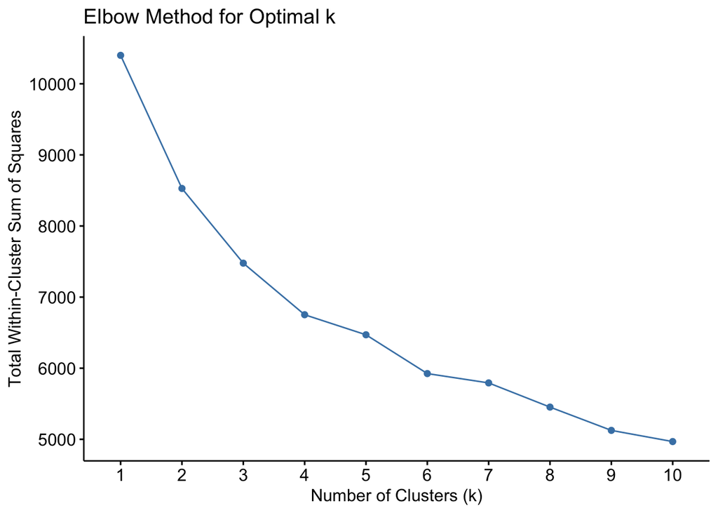

```r
#Elbow method
fviz_nbclust(diet_matrix, kmeans, method = "wss") +
  labs(title = "Elbow Method for Optimal k",
       x     = "Number of Clusters (k)",
       y     = "Total Within-Cluster Sum of Squares")
```

The gap statistic recommended k = 8 as the optimal solution (gap = 0.549, SE = 0.005). However, since the analysis included exactly 8 dietary variables, using k = 8 would essentially assign each variable its own cluster, which limits meaningful interpretation. In addition, the elbow plot showed the largest drop in within-cluster variation from k = 1 to k = 3. Based on both methods, **k = 3 was chosen as the final number of clusters to represent three distinct maternal dietary patterns.**

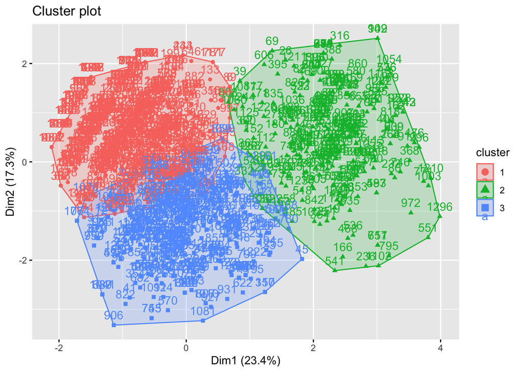

```r
set.seed(123)

km = diet_matrix %>%
  kmeans(centers = 3, nstart = 25)

fviz_cluster(km, data = diet_matrix)
```

```r
cluster_profile = cbind(
  df[, diet_vars] %>% mutate(across(everything(), as.numeric)),
  diet_cluster = km$cluster
)

cluster_profile %>%
  group_by(diet_cluster) %>%
  summarise_all(mean) %>%
  knitr::kable(digits = 2,
               caption = "Mean Dietary Intake by Cluster")
```

Mean Dietary Intake by Cluster

| diet_cluster | h_cereal_preg_Ter | h_dairy_preg_Ter | h_fastfood_preg_Ter | h_fish_preg_Ter | h_fruit_preg_Ter | h_legume_preg_Ter | h_meat_preg_Ter | h_veg_preg_Ter |
| --- | --- | --- | --- | --- | --- | --- | --- | --- |
| 1 | 1.64 | 2.69 | 2.64 | 2.09 | 2.17 | 2.95 | 2.04 | 1.42 |
| 2 | 2.74 | 2.18 | 1.71 | 2.29 | 2.29 | 1.17 | 2.35 | 1.69 |
| 3 | 1.52 | 1.68 | 2.63 | 1.98 | 2.47 | 2.37 | 1.84 | 2.57 |

```r
df$diet_cluster = factor(km$cluster)
knitr::kable(table(df$diet_cluster), col.names = c("Diet Cluster", "Total"))
```

| Diet Cluster | Total |
| --- | --- |
| 1 | 657 |
| 2 | 268 |
| 3 | 376 |

Three distinct maternal dietary patterns were identified using k-means clustering (k = 3), based on mean tertile scores across eight dietary food groups during pregnancy.

- **Cluster 1: High Legume/Dairy** (n = 657)

The highest legume (mean = 2.95) and dairy (mean = 2.69) intake among all clusters, suggesting a diet rich in plant-based protein and animal-sourced nutrients. Fast food consumption was also elevated (mean = 2.64).

- **Cluster 2: High Cereal/Meat** (n = 268)

The highest cereal (mean = 2.74), meat (mean = 2.35), and fish intake (mean = 2.29), reflecting a more Western-style dietary pattern with higher processed grain and animal protein consumption.

- **Cluster 3: High Vegetable/Fruit** (n = 376)

The highest vegetable (mean = 2.57) and fruit (mean = 2.47) intake, suggesting a diet with greater emphasis on plant-based foods.

*Note:* From **table 1**, fast food consumption was similarly elevated in Cluster 1 (2.64) and Cluster 3 (2.63), and significantly lower in Cluster 2 (1.71). This pattern may partly reflect the mixed nutritional composition of fast food items common, which usually include dairy, vegetables, and legumes. This probably makes elevated fast food consumption behaviorally compatible with otherwise distinct dietary profiles.

**Step 3: Data Partition**

The dataset was split into 70% training and 30% test sets using stratified partitioning to preserve the class distribution of `hs_asthma`. Data was partitioned to create one set of data to generate hypotheses and the other to test hypotheses.

```r
set.seed(123)

train_index = createDataPartition(df$hs_asthma, p = 0.7, list = FALSE)
train_data  = df[train_index, ]
test_data   = df[-train_index, ]

# Show sizes
cat("Training set:", nrow(train_data), "observations\n")
```

```
## Training set: 912 observations
```

```r
cat("Test set:    ", nrow(test_data), "observations\n")
```

```
## Test set:     389 observations
```

The dataset was randomly split into a training set (n = 912) and a test set (n = 389).

**Step 4: Supervised Learning (Logistic Regression, Elastic Net, and Random Forest)**

Up-sampling was applied to address class imbalance issues.

10-fold cross validation was used as it provides the most robust estimates for model performance, our sample size wasn’t too large so the computational cost was not too high.

Hyperparameters were tuned when possible to balance bias and variance and to reduce noise.

*Model 1:* Logistic regression was selected as it is useful in hypothesis generation when trying to find statistically significant associations, it is also the standard baseline.

```r
set.seed(123)

# 10-fold CV with upsampling for class imbalance
control_settings = trainControl(
  method          = "cv",
  number          = 10,
  sampling        = "up",
  classProbs      = TRUE,
  summaryFunction = twoClassSummary
)

l_model<- train(
  hs_asthma ~ .,
  data = train_data,
  method = "glm",
  trControl = control_settings,
  preProcess = c("center","scale"), #ranges for the variables are varied
  metric    = "ROC"
)
```

*Model 2:* Elastic Net was selected to handle correlation among dietary variables.

A penalty factor of zero was applied to all covariates to ensure they were always retained in the model regardless of regularization, to reduce the influence of sociodemographic factors. Dietary variables were penalized and subject to selection.

Hyperparameters `alpha` and `lambda` were tuned using a grid search with 10-fold cross-validation.

```r
set.seed(123)

# Build model matrix to get correct column names after dummy expansion
x_train = model.matrix(hs_asthma ~ . - diet_cluster, data = train_data)[, -1]

# Penalty factor: 0 = always kept (covariates), 1 = penalized (dietary vars)
covar_vars = c("e3_sex_None", "h_age_None", "h_edumc_None", "h_mbmi_None", "h_cohort")
penalty_vec = ifelse(grepl(paste(covar_vars, collapse = "|"), colnames(x_train)), 0, 1)

# Lambda grid
lambda  = 10^seq(-3, 1, length = 100)
en_grid = expand.grid(alpha = seq(0, 1, by = 0.1), lambda = lambda)

en_model = train(
  hs_asthma ~ . - diet_cluster,
  data           = train_data,
  method         = "glmnet",
  preProc        = c("center", "scale"),
  trControl      = control_settings,
  tuneGrid       = en_grid,
  metric         = "ROC",
  penalty.factor = penalty_vec
)

# Best tune
en_model$bestTune
```

```
##     alpha     lambda
## 728   0.7 0.01232847
```

*Model 3:* Random Forest was selected as it can handle non-linear relationships and interaction well.

```r
set.seed(123)

#mtry
num_predictors <- ncol(train_data) - 1
mtry.vals <- c(num_predictors, sqrt(num_predictors), 0.5 * num_predictors, 2 * num_predictors)
mtry.grid <- expand.grid(.mtry = round(mtry.vals))

rf_model <- train(
  hs_asthma ~ .,
  data = train_data,
  method = "rf",
  metric = "ROC",
  tuneGrid = mtry.grid,
  trControl = control_settings,
  ntree = 300,
  importance = TRUE
)

#best tune
rf_model$bestTune
```

```
##   mtry
## 1    4
```

**Step 5: Model Comparison**

```r
model_comparison <- resamples(list(
  Logistic = l_model,
  Elastic_Net = en_model,
  Random_Forest = rf_model
))

mc <- summary(model_comparison)
summary <- mc$statistics$ROC[, "Mean"]

knitr::kable(summary, col.names = c("Model", "Mean ROC"))
```

| Model | Mean ROC |
| --- | --- |
| Logistic | 0.6305827 |
| Elastic_Net | 0.6607046 |
| Random_Forest | 0.6072486 |

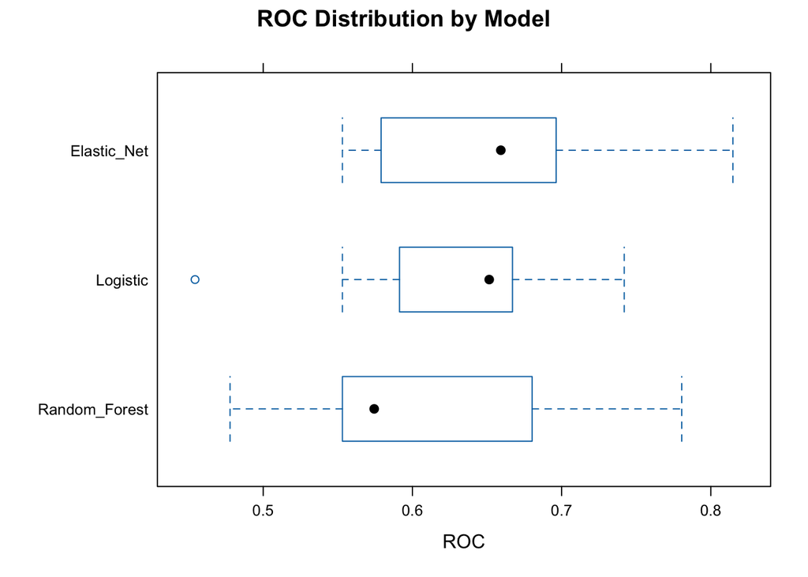

```r
bwplot(model_comparison, metric = "ROC", main = "ROC Distribution by Model")
```

The elastic net model had the largest mean ROC of 0.66. We will apply our elastic net model to our test set.

**Step 6: Apply Model**

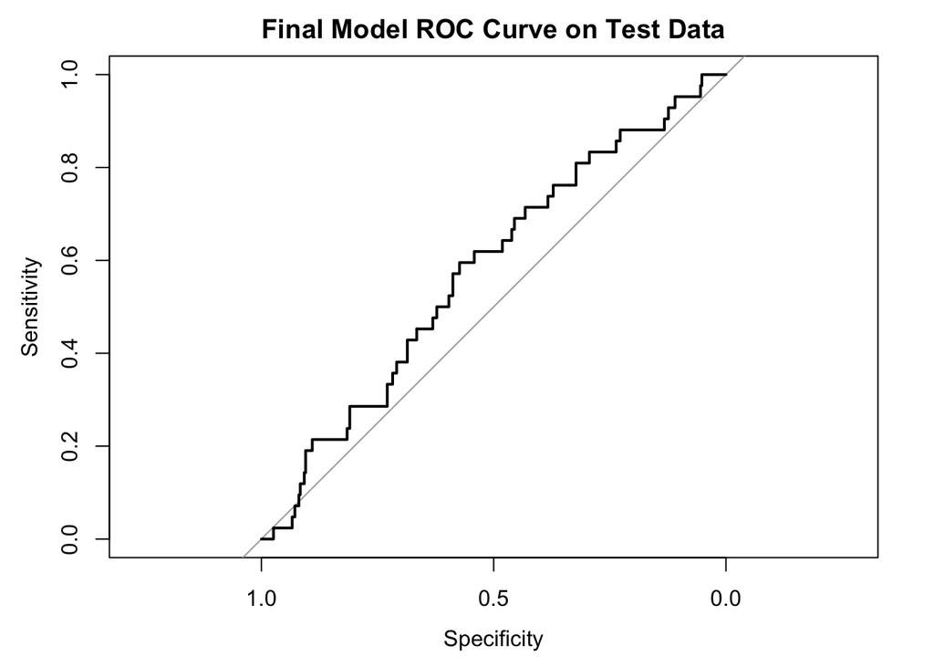

```r
final <- predict(en_model, test_data, type = "prob")
test_roc <- roc(test_data$hs_asthma, final$Yes)
plot(test_roc, main = "Final Model ROC Curve on Test Data")
```

```r
sen_spec <- predict(en_model, newdata = test_data)
confusionMatrix(sen_spec, test_data$hs_asthma, positive = "Yes")
```

```
## Confusion Matrix and Statistics
##
##           Reference
## Prediction  No Yes
##        No  210  21
##        Yes 137  21
##
##                Accuracy : 0.5938
##                  95% CI : (0.5432, 0.643)
##     No Information Rate : 0.892
##     P-Value [Acc > NIR] : 1
##
##                   Kappa : 0.0475
##
##  Mcnemar's Test P-Value : <2e-16
##
##             Sensitivity : 0.50000
##             Specificity : 0.60519
##          Pos Pred Value : 0.13291
##          Neg Pred Value : 0.90909
##              Prevalence : 0.10797
##          Detection Rate : 0.05398
##    Detection Prevalence : 0.40617
##       Balanced Accuracy : 0.55259
##
##        'Positive' Class : Yes
##
```

This model has weak sensitivity and weak specificity. It is also only accurate in its predictions about half the time. This suggests that the features included in this model don’t contain enough predictive power to accurately predict risk of asthma in offspring. The final ROC-AUC is 0.58.

**Step 7: Variable Importance**

```r
varImp(en_model)
```

```
## glmnet variable importance
##
##   only 20 most important variables shown (out of 26)
##
##                       Overall
## h_cohort3             100.000
## e3_sex_Nonemale        49.411
## h_cohort5              43.503
## h_cohort2              35.787
## h_meat_preg_Ter.L      26.257
## h_age_None             24.262
## h_fish_preg_Ter.Q      22.715
## h_legume_preg_Ter.L    21.395
## h_meat_preg_Ter.Q      16.227
## h_cereal_preg_Ter.Q    13.724
## h_edumc_None2          13.153
## h_veg_preg_Ter.Q       13.151
## h_cohort6              12.989
## h_edumc_None3           9.744
## h_dairy_preg_Ter.Q      7.392
## h_fish_preg_Ter.L       7.338
## h_mbmi_None             5.652
## h_fastfood_preg_Ter.Q   3.720
## h_cohort4               2.153
## h_fruit_preg_Ter.L      1.364
```

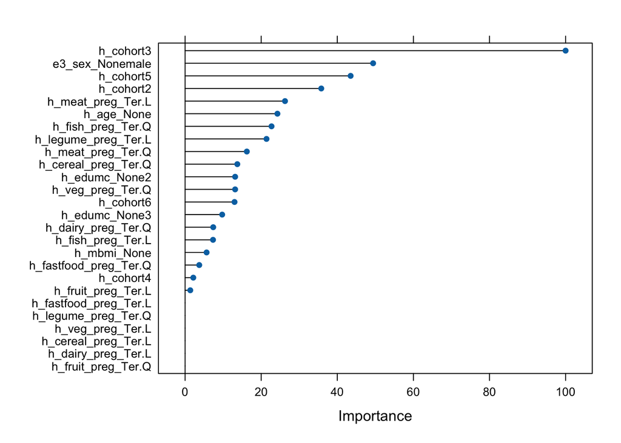

```r
plot(varImp(en_model))
```

The most important dietary predictors of asthma were found to be meat and fish consumption during pregnancy.

#### **Interpretation**

Results from our analytic pipeline indicate that the selected dietary features did not have enough predictive power to accurately predict asthma cases (*test ROC-AUC = 0.58*). However, while our model was not highly accurate, our findings suggest that meat consumption during pregnancy may contribute to asthma incidence in offspring, as it showed the highest variable importance among all dietary features in the Elastic Net model. Fish and legume consumption during pregnancy also appeared as notable dietary predictors. Future research into diet and asthma should consider these exposures.

For covariates, `h_cohort3`, `h_cohort5`, and `h_cohort2` ranked among the top four predictors overall. This likely reflects the fact that the six HELIX cohorts represent different European countries, each with distinct dietary cultures, asthma prevalence rates, and environmental contexts. Therefore, some of the model’s predictive signal may reflect national differences rather than specific dietary behaviors, which limits how we can attribute predictive importance to individual foods confidently.

Our findings should not be used in clinical or real-world settings. No causal inference or definitive statements of association can be made from our findings, as this study is hypothesis-generating in nature. Although sociodemographic covariates were included as features, this study focused on dietary exposures and unmeasured confounders cannot be fully accounted for. We can only recommend that research into maternal diet and asthma be informed by our findings. If significant, findings from that research would be helpful to expecting parents who may be able to modify their diets to reduce asthma risk in their offspring.

#### **Limitations**

A major limitation of the research is that the dietary variables included were tertile-coded, which may obscure true variation in intake and limit precision of the dietary patterns identified. By assuming constant risk within each tertile, we likely lost statistical power. This may explain the lack of predictive power that we found. Additionally, the HELIX cohort is limited to six European countries, which may limit generalizability to populations outside Europe. We also used up-sampling to handle the class imbalance between asthma cases and controls. This may have led to overfitting which would further reduce the generalizability of our results. While the Elastic Net model forced covariates into the model via a zero penalty factor, full confounding adjustment in the causal sense is not possible in a predictive framework. Residual confounding from unmeasured factors (e.g., smoking, indoor allergens, antibiotic use) cannot be ruled out.

#### **Ethical Considerations**

Dietary patterns are shaped by socioeconomic and cultural factors. Results should not be used to stigmatize individuals with limited food access, and any future research should account for structural barriers to healthy eating. Moreover, our dataset relies on European data and best informs research done on similar populations. For instance, research into meat consumption as a cause for asthma may not be beneficial in areas with greater vegetarian populations.

#### **References**

1. Kim, Tae Hyeon et al. “Global burden of asthma among children and adolescents with projections to 2050: a comprehensive review and forecasted modeling study.” *Clinical and experimental pediatrics* vol. 68,5 (2025): 329-343. doi:10.3345/cep.2025.00423
2. Agier, Lydiane, et al. “Early-life exposome and lung function in children in Europe: an analysis of data from the longitudinal, population-based HELIX cohort.” *The Lancet Planetary Health* 3.2 (2019): e81-e92.

#### **AI tools**

Claude.ai was used in this assignment to assist with debugging R code syntax errors and editing text for clarity and conciseness.